# Ο διάμεσος με ολοκληρώματα

Συνοδευτικό του «Μέσος όρος και απόκλιση με ολοκληρώματα»

Συγγραφέας

[Kostas Maistrelis](https://maistrelis.com)

Δημοσιευμένο

28 Σεπτεμβρίου 2026

Στο κυρίως κείμενο, ο μέσος όρος και η απόκλιση περιγράφονταν με **έναν** τύπο: $\int (\text{ποσότητα}) \cdot (\text{βάρος})\,dx$. Ο διάμεσος δεν ακολουθεί αυτό το μοτίβο. Δεν είναι μέσος όρος κάποιας ποσότητας, αλλά **η τιμή που χωρίζει τα βάρη στη μέση**. Γι’ αυτό τον εξετάζουμε χωριστά.

Η σειρά είναι η ίδια με το κυρίως κείμενο: πρώτα απλές συναρτήσεις, μετά πυκνότητες.

## Διάμεσος των τιμών μιας συνάρτησης

Για $n$ αριθμούς, ο διάμεσος είναι η τιμή κάτω από την οποία βρίσκονται οι μισοί αριθμοί και πάνω από την οποία βρίσκονται οι άλλοι μισοί. Για τις τιμές μιας συνάρτησης $h(x)$ στο $[a, b]$, το «μισοί» γίνεται «για το μισό μήκος του διαστήματος»:

> Διάμεσος είναι η τιμή $M$ για την οποία $h(x) \le M$ σε μήκος $\frac{b-a}{2}$ του διαστήματος και $h(x) \ge M$ στο υπόλοιπο.

### Για αύξουσες συναρτήσεις: η τιμή στο μέσο

Αν η $h$ είναι **αύξουσα**, όσο προχωράμε προς τα δεξιά οι τιμές μεγαλώνουν. Οι μικρότερες τιμές βρίσκονται λοιπόν στο αριστερό μισό του διαστήματος και οι μεγαλύτερες στο δεξί. Άρα ο διάμεσος είναι απλώς η τιμή στο **μέσο** του διαστήματος:

$$M = h\!\left(\frac{a + b}{2}\right)$$

Αυτή είναι η πρώτη ιδιαιτερότητα του διαμέσου. Στις μη μονότονες συναρτήσεις —π.χ. σε ένα ημίτονο που ανεβοκατεβαίνει— οι μικρές τιμές σκορπίζονται σε πολλά κομμάτια του διαστήματος, και ο υπολογισμός γίνεται πολύ πιο δύσκολος. Εδώ μένουμε σε αύξουσες.

**Κώδικας**

```r
a <- 0
b <- 1
h_lin <- function(x) 2 * x
h_cvx <- function(x) x^2
h_ccv <- function(x) 2 * x - x^2

mean_values   <- function(h) integrate(h, a, b)$value / (b - a)
median_values <- function(h) h((a + b) / 2)   # ισχύει επειδή η h είναι αύξουσα

sapply(list(`2x` = h_lin, `x²` = h_cvx, `2x − x²` = h_ccv),
       function(h) c(`μέσος` = mean_values(h), `διάμεσος` = median_values(h)))
```

```
         2x        x²   2x − x²
μέσος     1 0.3333333 0.6666667
διάμεσος  1 0.2500000 0.7500000
```

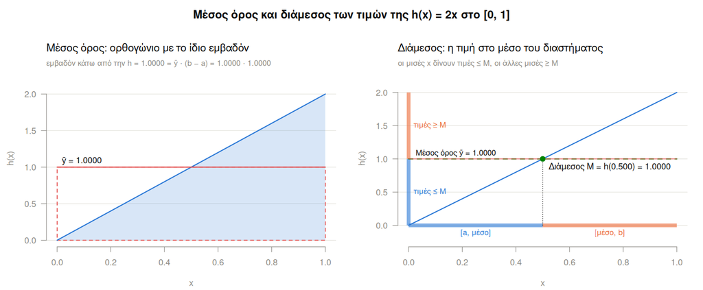

Εικόνα 1: Μέσος όρος και διάμεσος των τιμών της $h(x) = 2x$. Αριστερά: ο μέσος όρος ως ύψος ορθογωνίου ίσου εμβαδού. Δεξιά: ο διάμεσος ως η τιμή στο μέσο του διαστήματος. (`function_values.R`)

Στο δεξί πάνελ της Εικόνα 1 το διάστημα $[a, b]$ χωρίζεται στη μέση πάνω στον άξονα $x$, με μια μπλε και μια πορτοκαλί μπάρα. Επειδή η $h$ ανεβαίνει, το μπλε μισό δίνει τις τιμές κάτω από το $M$ και το πορτοκαλί τις τιμές πάνω από το $M$. Φαίνονται ως οι αντίστοιχες μπάρες στον άξονα $y$. Για την ευθεία, μέσος όρος και διάμεσος **συμπίπτουν** ($= 1$), και οι δύο γραμμές πέφτουν η μία πάνω στην άλλη.

### Κυρτή και κοίλη: ο μέσος όρος ξεφεύγει

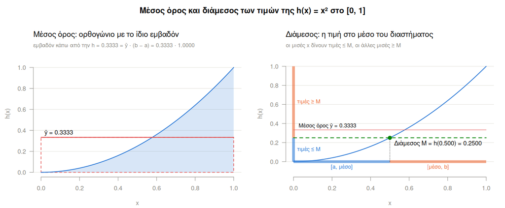

Εικόνα 2: Μέσος όρος και διάμεσος των τιμών της $h(x) = x^2$ (κυρτή). (`function_values.R`)

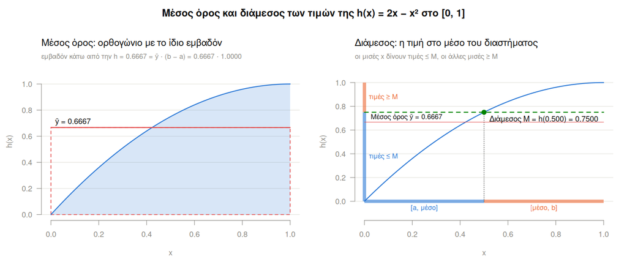

Εικόνα 3: Μέσος όρος και διάμεσος των τιμών της $h(x) = 2x - x^2$ (κοίλη). (`function_values.R`)

| Σχήμα | Παράδειγμα | Μέσος | Διάμεσος | Σχέση |
| --- | --- | --- | --- | --- |
| ευθεία | $2x$ | 1 | 1 | μέσος **=** διάμεσος |
| κυρτή (λυγίζει πάνω) | $x^2$ | 1/3 | 1/4 | μέσος **>** διάμεσος |
| κοίλη (λυγίζει κάτω) | $2x - x^2$ | 2/3 | 3/4 | μέσος **<** διάμεσος |

Στην Εικόνα 2 η καμπύλη μένει χαμηλά για πολύ καιρό και ανεβαίνει απότομα στο τέλος. Λίγα $x$ κοντά στο 1 δίνουν πολύ μεγάλες τιμές. Ο **μέσος όρος** τις λαμβάνει υπόψη με το πραγματικό τους μέγεθος, οπότε ανεβαίνει. Ο **διάμεσος** κοιτάζει μόνο **πόσες** τιμές είναι πάνω και κάτω, όχι **πόσο μεγάλες** είναι, οπότε δεν επηρεάζεται. Στην Εικόνα 3 συμβαίνει το ανάποδο: λίγες πολύ μικρές τιμές στην αρχή τραβάνε τον μέσο όρο προς τα κάτω.

Υπάρχει και ένας κομψός τρόπος να το δει κανείς. Ο διάμεσος των $x$ στο $[a, b]$ είναι το μέσο $\frac{a+b}{2}$, και ο μέσος όρος τους είναι επίσης το $\frac{a+b}{2}$. Για αύξουσα $h$:

- ο **διάμεσος** των τιμών είναι πάντα $h(\text{μέσο})$,
- ο **μέσος όρος** των τιμών είναι $h(\text{μέσο})$ **μόνο** για ευθεία. Για κυρτή είναι μεγαλύτερος και για κοίλη μικρότερος.

Ο διάμεσος «περνάει μέσα» από μια αύξουσα συνάρτηση, ενώ ο μέσος όρος όχι.

## Διάμεσος μιας πυκνότητας

Στις πυκνότητες η τιμή είναι η θέση $x$ και το ύψος $f(x)$ είναι το βάρος (δες τη μετάβαση στο κυρίως κείμενο). Ο διάμεσος $m$ είναι η θέση που χωρίζει το **συνολικό βάρος** στα δύο: 50% αριστερά, 50% δεξιά.

$$F(m) = \int_{-\infty}^{m} f(x)\,dx = 0.5$$

Η $F$ λέγεται **αθροιστική συνάρτηση κατανομής**. Εδώ είναι η δεύτερη ιδιαιτερότητα του διαμέσου: ο άγνωστος είναι το **άνω όριο** του ολοκληρώματος, όχι το αποτέλεσμά του. Δεν αρκεί λοιπόν να υπολογίσουμε ένα ολοκλήρωμα. Πρέπει να **ψάξουμε** το $m$ που κάνει την εξίσωση αληθή. Αυτό το κάνει η `uniroot()`: βρίσκει πού μηδενίζεται η $F(m) - 0.5$.

**Κώδικας**

```r
f <- function(x) (1 / sqrt(2 * pi)) * exp(-x^2 / 2)

F <- function(m) integrate(f, -Inf, m)$value
m <- uniroot(function(m) F(m) - 0.5, interval = c(-5, 5), tol = 1e-10)$root
m
```

```
[1] 2.579831e-10
```

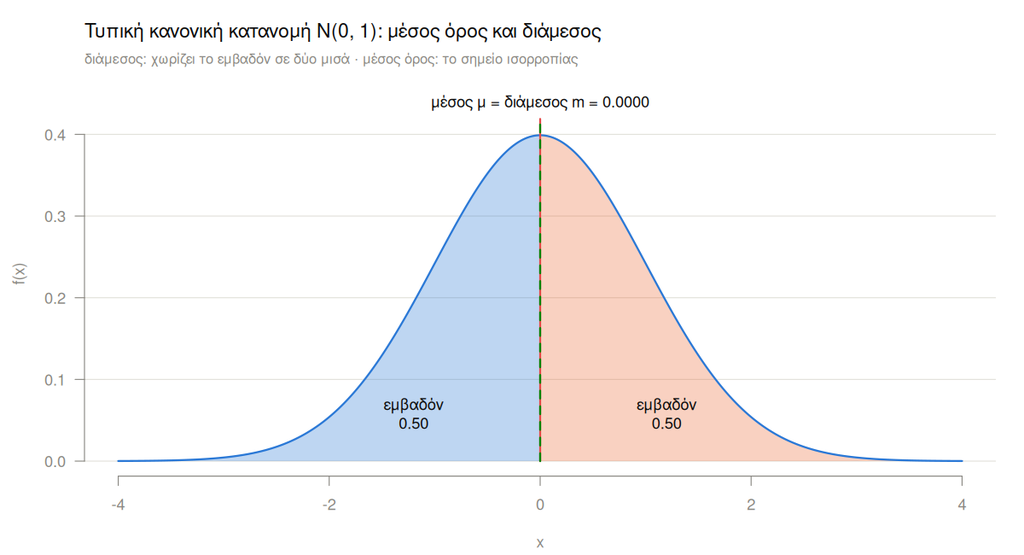

Εικόνα 4: Τυπική κανονική κατανομή. Ο διάμεσος (πράσινη διακεκομμένη) χωρίζει το εμβαδόν σε δύο ίσα μισά: μπλε αριστερά, πορτοκαλί δεξιά. Ο μέσος όρος (κόκκινη) πέφτει στο ίδιο σημείο. (`normal_mean_median.R`)

Στην Εικόνα 4 η μπλε περιοχή είναι το ολοκλήρωμα $F(m)$: ακριβώς το μισό βάρος. Επειδή η κανονική είναι συμμετρική, μέσος όρος και διάμεσος **συμπίπτουν** στο 0, όπως στην ευθεία της Εικόνα 1.

### Μη συμμετρική: η κανονική σε διάστημα

Αν κρατήσουμε την κανονική καμπύλη μόνο στο $[-0.5, 2]$ (λεπτομέρειες στο συνοδευτικό κείμενο για το διάστημα), η κατανομή παύει να είναι συμμετρική. Κόβεται νωρίς αριστερά αλλά απλώνεται ως το 2 δεξιά.

**Κώδικας**

```r
lo <- -0.5
hi <- 2
Z <- integrate(f, lo, hi)$value
g <- function(x) f(x) / Z                       # κανονικοποιημένη πυκνότητα

mu_ab <- integrate(function(x) x * g(x), lo, hi)$value
m_ab  <- uniroot(function(m) integrate(g, lo, m)$value - 0.5,
                 interval = c(lo, hi), tol = 1e-10)$root
c(`μέσος` = mu_ab, `διάμεσος` = m_ab)
```

```
    μέσος  διάμεσος
0.4457438 0.3662044
```

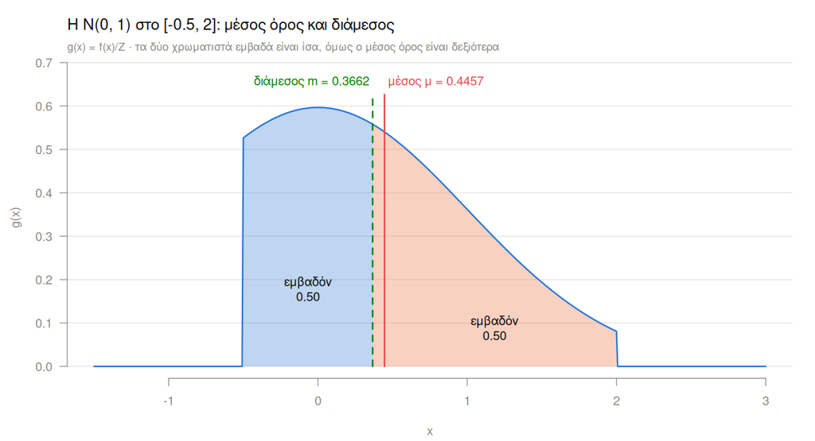

Εικόνα 5: Η κανονική στο $[-0.5, 2]$. Μπλε: το μισό βάρος $[a, m]$. Πορτοκαλί: το άλλο μισό $[m, b]$. Ο μέσος όρος (κόκκινη) είναι δεξιότερα από τον διάμεσο (πράσινη). (`normal_mean_median_interval.R`)

Στην Εικόνα 5 τα δύο χρωματιστά εμβαδά είναι ίσα, γιατί αυτός είναι ο ορισμός του διαμέσου. Ο μέσος όρος όμως ($\approx 0.446$) είναι δεξιότερα από τον διάμεσο ($\approx 0.366$). Ο λόγος είναι ο ίδιος με την κυρτή συνάρτηση: οι λίγες μακρινές τιμές στα δεξιά μετράνε στον μέσο όρο με την απόστασή τους, ενώ στον διάμεσο μετράνε απλώς ως «μία ακόμα τιμή δεξιά».

## Σύνοψη

|  | Απλή συνάρτηση (αύξουσα) | Πυκνότητα |
| --- | --- | --- |
| ορισμός | $h(x) \le M$ στο μισό μήκος του $[a, b]$ | $\int_{-\infty}^{m} f(x)\,dx = 0.5$ |
| υπολογισμός | $M = h\!\left(\frac{a+b}{2}\right)$ | αναζήτηση με `uniroot()` |
| ίσος με τον μέσο όρο όταν | η $h$ είναι ευθεία | η $f$ είναι συμμετρική |

Γιατί ο διάμεσος είναι σε χωριστό κείμενο:

1. **Δεν είναι μέσος όρος κάποιας ποσότητας**, οπότε δεν χωράει στο $\int (\text{ποσότητα}) \cdot (\text{βάρος})\,dx$.
2. **Ο άγνωστος είναι όριο ολοκλήρωσης**, οπότε χρειάζεται αναζήτηση και όχι απλός υπολογισμός.
3. **Στις απλές συναρτήσεις απαιτεί μονοτονία**, αλλιώς γίνεται πολύπλοκος.

Η δύναμή του είναι ότι **δεν επηρεάζεται από το πόσο μακριά** είναι οι ακραίες τιμές. Γι’ αυτό, όταν ο μέσος όρος και ο διάμεσος διαφέρουν, η διαφορά τους δείχνει προς τα πού «τραβάει» η κατανομή.

## Ασκήσεις

**1.** Υπολόγισε μέσο όρο και διάμεσο των τιμών της $h(x) = x^3$ στο $[0, 1]$. Ποιος είναι μεγαλύτερος, και ταιριάζει με το ότι η $x^3$ είναι κυρτή;

**ΣυμβουλήΛύση**

Μέσος $= \int_0^1 x^3\,dx = 1/4$, διάμεσος $= h(0.5) = 1/8$. Ο μέσος είναι **μεγαλύτερος**, όπως σε κάθε κυρτή συνάρτηση. Η διαφορά είναι μάλιστα μεγαλύτερη από εκείνη της $x^2$ ($1/3$ έναντι $1/4$), γιατί η $x^3$ λυγίζει ακόμη περισσότερο.

**2.** Η $f(x) = 2x$ στο $[0, 1]$ είναι πυκνότητα με μέσο όρο $2/3$ (δες την άσκηση 4 του κυρίως κειμένου). Βρες τον διάμεσό της με το χέρι. Είναι πάνω ή κάτω από τον μέσο όρο;

**ΣυμβουλήΛύση**

$F(m) = \int_0^m 2x\,dx = m^2 = 0.5$, άρα $m = 1/\sqrt{2} \approx 0.707$. Εδώ η εξίσωση λύνεται με το χέρι, χωρίς `uniroot`. Ο διάμεσος είναι **πάνω** από τον μέσο όρο ($0.667$). Υπάρχει λίγο βάρος κοντά στο 0 και πολύ βάρος κοντά στο 1, οπότε η «ουρά» είναι αριστερά και τραβάει τον μέσο όρο προς τα εκεί.

**Κώδικας**

```r
uniroot(function(m) integrate(function(x) 2 * x, 0, m)$value - 0.5, c(0, 1))$root
```

```
[1] 0.7071067
```

## Συντελεστές

Συγγραφή: [Kostas Maistrelis](https://maistrelis.com) (ORCID 0000-0002-0851-2866). Το κείμενο, οι εικόνες και ο κώδικας R αναπτύχθηκαν σε συνεργασία με το [Claude](https://www.anthropic.com/claude) της Anthropic.

Γλωσσική επιμέλεια: [Codex](https://openai.com/codex/) της OpenAI.

## Άδεια χρήσης

Το κείμενο και οι εικόνες διατίθενται με την άδεια [Creative Commons Αναφορά Δημιουργού 4.0 (CC BY 4.0)](https://creativecommons.org/licenses/by/4.0/deed.el): μπορείς να τα χρησιμοποιήσεις, να τα αλλάξεις και να τα μοιραστείς, αρκεί να αναφέρεις την πηγή. Ο κώδικας (τα scripts R, το Makefile και τα κομμάτια κώδικα του κειμένου) διατίθεται με την άδεια [MIT](https://opensource.org/license/mit).